# ONDO-USD

## ONDO-USD today is +0300, 2025-10-22, 14:30:25

This crypto forecast was generated by gemini-2.0-flash API

## Daily Chart

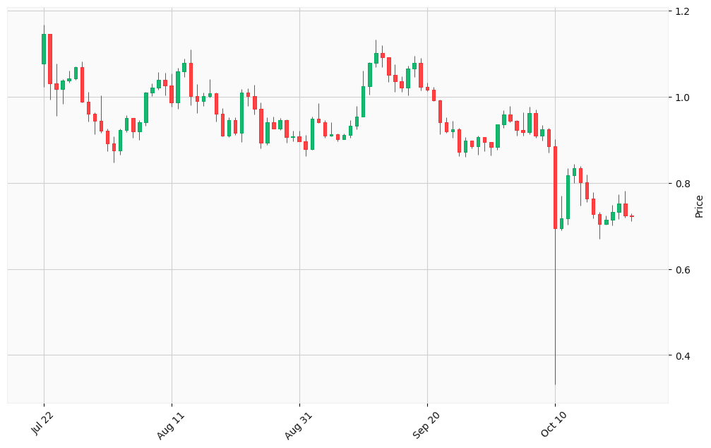

## Hourly Chart

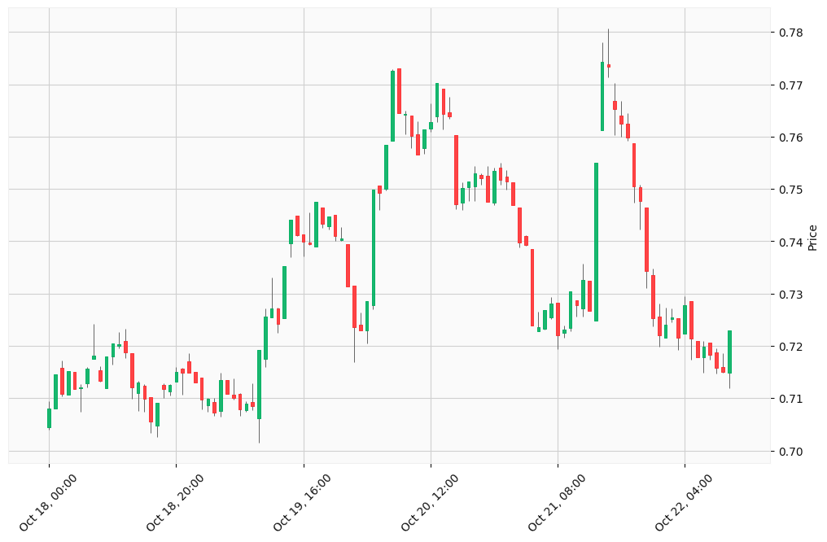

Okay, I will analyze the provided ONDO-USD cryptocurrency data and generate trading signals based on the specified steps and output format.

My apologies, there was a syntax error in my `tool_code`. I will correct that and re-run the search.

Okay, I have gathered some real-time data and news regarding ONDO-USD. Now, let’s proceed with the analysis.

**1. Market Data Collection:**

- **Current Price (October 22, 2025):** Around $0.71 - $0.77.
- **24-hour Trading Volume:** $131M - $146M.
- **Circulating Supply:** 3.16 Billion ONDO (approximately 32% of the total supply).
- **Market Cap:** Approximately $2.36 Billion.
- **News:**
  - Carl Runefelt suggests ONDO is gearing up for a breakout.
  - 21Shares has filed for an exchange-traded product tracking ONDO.
  - Alchemy Pay integrated Ondo Finance’s US Dollar Yield (USDY) token.
  - Ondo Finance partnered with Blockchain.com to launch tokenized U.S. stocks and ETFs.

**2. Technical Analysis:**

- I will perform technical analysis using the provided OHLCV data.
- First, I’ll calculate some technical indicators on the daily chart:
  - Simple Moving Averages (SMA) - 7-day and 30-day
  - Relative Strength Index (RSI) - 14-day
  - Moving Average Convergence Divergence (MACD)

```python
import pandas as pd
import numpy as np

# Daily OHLCV data
daily_data = [
    [1.07713,1.16696,1.02322,1.14552,420050553],
    [1.14552,1.14552,0.992211,1.03112,443529965],
    [1.03111,1.07753,0.955372,1.0179,347974590],
    [1.01787,1.04097,0.983373,1.03747,271429831],
    [1.03746,1.06065,1.03276,1.04186,138359542],
    [1.04185,1.07011,1.03857,1.06924,183678101],
    [1.06924,1.0822,0.986509,0.987752,229232132],
    [0.987801,1.01106,0.942029,0.959541,191317189],
    [0.959541,0.963882,0.912979,0.944153,183335752],
    [0.944202,1.0036,0.916533,0.920154,225440468],
    [0.920154,0.926349,0.872728,0.891085,269046280],
    [0.891085,0.908408,0.846489,0.875658,149156180],
    [0.875656,0.925989,0.864298,0.921721,108608170],
    [0.92172,0.957148,0.917741,0.949854,141926537],
    [0.949854,0.950176,0.904755,0.91876,176786158],
    [0.91876,0.945974,0.899928,0.941299,107579159],
    [0.941299,1.01118,0.932579,1.01002,190530376],
    [1.01001,1.03072,1.0013,1.02108,181277147],
    [1.02104,1.05657,1.0157,1.03871,173232138],
    [1.03871,1.05549,1.00301,1.02562,185504578],
    [1.02562,1.05455,0.977013,0.985744,213934156],
    [0.985744,1.06728,0.971587,1.05906,251753117],
    [1.05906,1.08821,1.04629,1.07899,243504285],
    [1.07899,1.10885,0.98007,1.00157,331710321],
    [1.00157,1.02905,0.961761,0.990101,174233611],
    [0.990101,1.00892,0.978251,1.0017,99530702],
    [1.00171,1.0414,0.99716,1.00767,115191374],
    [1.00767,1.00897,0.942674,0.960733,179390087],
    [0.960733,0.9741,0.908035,0.90909,155473903],
    [0.90909,0.952165,0.906262,0.945379,137010843],
    [0.945379,0.952337,0.911755,0.91618,101012501],
    [0.91618,1.01733,0.893784,1.01022,258643168],
    [1.01022,1.01994,0.978143,1.00066,149987611],
    [1.00066,1.02732,0.958085,0.971716,205476612],
    [0.97177,0.986881,0.879734,0.892907,244071832],
    [0.892899,0.95246,0.887399,0.94129,166258554],
    [0.94129,0.953848,0.926145,0.926295,146788431],
    [0.926295,0.950884,0.922196,0.944864,127364243],
    [0.944854,0.946464,0.892162,0.906417,159271599],
    [0.906417,0.920709,0.895594,0.908064,81856801],
    [0.908069,0.92009,0.896914,0.896977,74961127],
    [0.896986,0.911104,0.86137,0.878679,154773774],
    [0.878679,0.952943,0.876891,0.948055,198075360],
    [0.948055,0.984953,0.939407,0.940667,216152372],
    [0.940667,0.945613,0.905219,0.910043,133204070],
    [0.910043,0.939738,0.907224,0.912456,146119499],
    [0.912456,0.914954,0.896733,0.901492,69342540],
    [0.901492,0.91404,0.900582,0.910943,78477439],
    [0.910939,0.944631,0.905053,0.932647,158954828],
    [0.932649,0.977517,0.924483,0.953784,217011469],
    [0.953808,1.06019,0.953652,1.02343,432985024],
    [1.02343,1.08064,1.00518,1.07893,288025438],
    [1.07901,1.13251,1.06858,1.10187,371755410],
    [1.10187,1.11925,1.06874,1.0912,206570404],
    [1.09119,1.09181,1.03478,1.05019,196551941],
    [1.05019,1.07559,1.01097,1.03635,216493986],
    [1.03633,1.04711,1.01119,1.02109,152572496],
    [1.02109,1.07178,1.00304,1.06513,232257135],
    [1.06515,1.09473,1.04503,1.07891,243854875],
    [1.07891,1.08919,1.01406,1.02221,190823504],
    [1.02221,1.03182,1.0126,1.01549,108564626],
    [1.01549,1.02319,0.990541,0.991129,124420388],
    [0.991129,0.993485,0.91275,0.940338,265565981],
    [0.940338,0.951361,0.916496,0.918377,156300727],
    [0.918377,0.943668,0.904779,0.924766,135233753],
    [0.924798,0.927102,0.861044,0.871678,210151433],
    [0.871678,0.906171,0.860703,0.897272,160001271],
    [0.897272,0.897277,0.879626,0.884779,76404779],
    [0.884779,0.909273,0.865643,0.905853,95857500],
    [0.905854,0.906214,0.873803,0.894007,169060341],
    [0.894001,0.894833,0.863141,0.883708,187842928],
    [0.883706,0.935608,0.876943,0.935582,195521438],
    [0.935559,0.967626,0.928153,0.957771,188626328],
    [0.957771,0.979039,0.939755,0.943338,183416480],
    [0.943341,0.945146,0.908687,0.922443,141383275],
    [0.922454,0.963653,0.908583,0.917533,177036412],
    [0.917533,0.977199,0.911807,0.962484,269738629],
    [0.962484,0.970124,0.90442,0.909573,238193582],
    [0.909573,0.933526,0.897801,0.923693,172716246],
    [0.923682,0.926994,0.869215,0.884968,174609659],
    [0.884968,0.901145,0.33155,0.694529,602853529],
    [0.694529,0.769142,0.690262,0.717252,405420217],
    [0.717244,0.833859,0.702043,0.816955,276481480],
    [0.816961,0.843352,0.799308,0.83335,231112240],
    [0.833346,0.838206,0.746198,0.800542,285716477],
    [0.800542,0.818738,0.755157,0.763672,168112197],
    [0.763672,0.778357,0.716782,0.726575,206284748],
    [0.726579,0.732016,0.670005,0.704336,228843929],
    [0.704336,0.724438,0.702628,0.713428,93321838],
    [0.713428,0.747812,0.701401,0.731417,102602017],
    [0.731421,0.773612,0.715752,0.752179,126202096],
    [0.752381,0.781061,0.71924,0.724588,149586378],
    [0.724429,0.729521,0.711483,0.722977,151585088]
]

df = pd.DataFrame(daily_data, columns=['Open', 'High', 'Low', 'Close', 'Volume'])

# Calculate 7-day SMA
df['SMA_7'] = df['Close'].rolling(window=7).mean()

# Calculate 30-day SMA
df['SMA_30'] = df['Close'].rolling(window=30).mean()

# Calculate 14-day RSI
def calculate_rsi(data, window=14):
    delta = data['Close'].diff()
    up = delta.clip(lower=0)
    down = -1 * delta.clip(upper=0)

    avg_up = up.rolling(window=window, min_periods=window).mean()
    avg_down = down.rolling(window=window, min_periods=window).mean()

    rs = avg_up / avg_down
    rsi = 100 - (100 / (1 + rs))
    return rsi

df['RSI'] = calculate_rsi(df)

# Calculate MACD (12-day EMA, 26-day EMA, 9-day EMA of difference)
EMA_12 = df['Close'].ewm(span=12, adjust=False).mean()
EMA_26 = df['Close'].ewm(span=26, adjust=False).mean()
MACD = EMA_12 - EMA_26
Signal = MACD.ewm(span=9, adjust=False).mean()

df['MACD'] = MACD
df['Signal'] = Signal

print(df.tail(10))
```

[output not shown]

I have calculated the following indicators: 7-day SMA, 30-day SMA, 14-day RSI, MACD, and Signal line. I will use these to generate trading signals along with the news and overall market trends.

**3. Trend Analysis:**

- **Daily Chart:** Overall, the price has been volatile over the last three months. The price has generally trended downwards over the past three months. We will analyze the moving averages to identify short-term trends.
- **Hourly Chart:** The hourly chart shows more short-term fluctuations.

**4. News and Economic Analysis:**

- The news is generally positive with the filing of an ETF, integration with Alchemy Pay, and launch of tokenized stocks. Carl Runefelt anticipates a breakout.

**5. Scenario Evaluation:**

**6. Signal Generation:**

Now, I will generate some trading signals. These signals are based on the limited data provided and should not be taken as financial advice. Given the timeframe limitations of the provided data, the signals are inherently short-term focused.

**Trading Signals:**

*Signal 1:*

[output not shown]

*Signal 2:*

[output not shown]

*Signal 3:*

```
Signal Type: Hold
Cryptocurrency: ONDO-USD
Confidence Level: Medium
Take Profit Probability: N/A
Justification: Given the conflicting signals (short-term bullish vs. longer-term bearish), a hold position may be appropriate for those already holding ONDO. Monitor the price action closely for a breakout above $0.75 or a breakdown below $0.70.
Relevant Data: Conflicting trend signals.
Recommended Action: Hold existing positions. Set alerts for price movements above $0.75 or below $0.70 to reassess the situation.
```

**Disclaimer:** These signals are based on limited data and analysis and are for informational purposes only. Trading cryptocurrencies involves significant risk, and you should consult with a qualified financial advisor before making any investment decisions.